# (Exploratory Data Analysis: Loan Data from Prosper)

### Explore the the relationship between the features 'StatedMonthlyIncome', 'MonthlyLoanPayment' and 'Term'.

```python
df['MonthlyLoanPayment'].describe()
```

```
count    113937.000000
mean        272.475783
std         192.697812
min           0.000000
25%         131.620000
50%         217.740000
75%         371.580000
max        2251.510000
Name: MonthlyLoanPayment, dtype: float64
```

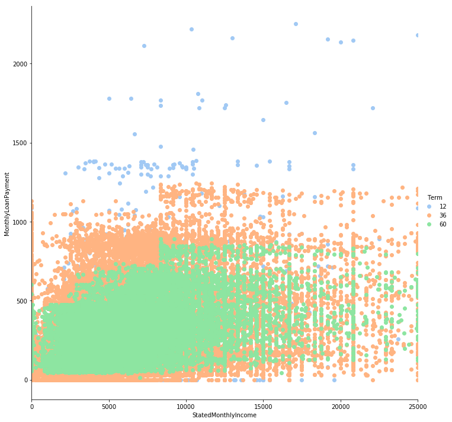

```python
g = sb.FacetGrid(data=df, hue='Term', size=10, palette='pastel')
g.map(plt.scatter, 'StatedMonthlyIncome', 'MonthlyLoanPayment')
plt.xlim((0, 25000))
g.add_legend();
```

We can find from the plot above that majority of Prosper loans fall under 36 to 60 months term owing to lower feature value of 'MonthlyLoanPayment' when compared to the 12 month term.

### Explore the the relationship between the features 'Recommendations', 'EstimatedLoss' and 'LoanStatus'.

```python
df['Recommendations'].dtype
```

```
dtype('int64')
```

```python
df['Recommendations'].describe()
```

```
count    113937.000000
mean          0.048027
std           0.332353
min           0.000000
25%           0.000000
50%           0.000000
75%           0.000000
max          39.000000
Name: Recommendations, dtype: float64
```

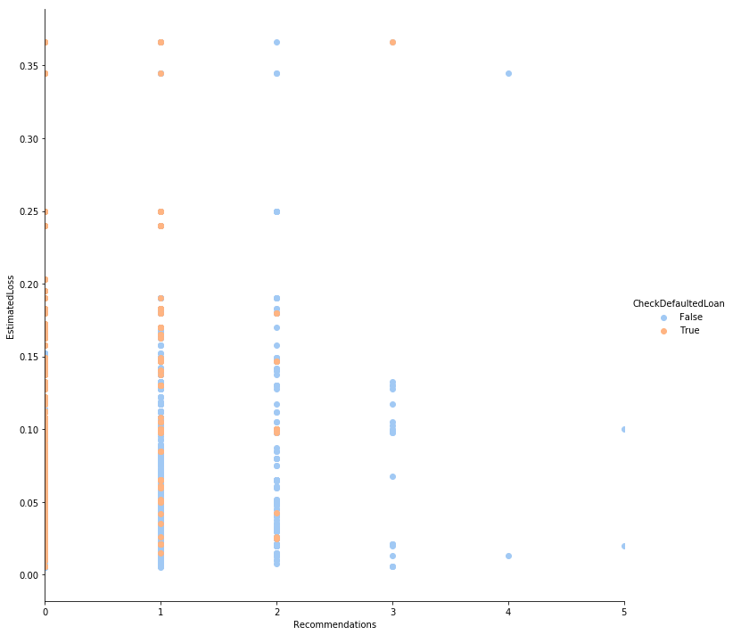

```python
g = sb.FacetGrid(data=df, hue='CheckDefaultedLoan', size=10, palette='pastel')
g.map(plt.scatter, 'Recommendations', 'EstimatedLoss')
plt.xlim((0, 5))
g.add_legend();
```

### Explore the the relationship between the features 'ProsperRating (numeric)', 'EstimatedLoss' and 'LoanStatus'.

```python
df['EstimatedReturn'].describe()
```

```
count    84853.000000
mean         0.096068
std          0.030403
min         -0.182700
25%          0.074080
50%          0.091700
75%          0.116600
max          0.283700
Name: EstimatedReturn, dtype: float64
```

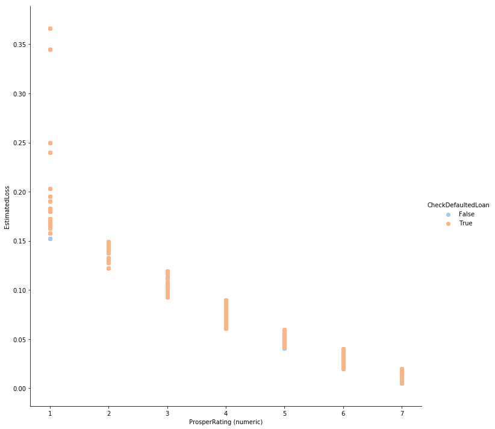

```python
g = sb.FacetGrid(data=df, hue='CheckDefaultedLoan', size=10, palette='pastel')
g.map(plt.scatter, 'ProsperRating (numeric)', 'EstimatedLoss')
g.add_legend();
```

We find from the plot above that as the prosper rating increases the estimated loss shows a marked decrease indicating that Prosper has a strong rating mechanism to avoid defaulted or charged off loans which might result in loss.

### Multivariate Analysis

#### Also included are cases of distributions with possible operations on the data to tidy, adjust, or change the form of the data

- As the 'ProsperRating (numeric)' move from lower to higher values of 1 to 7, 'DebtToIncomeRatio' as well as 'BorrowerRate' decreases.
- 'StatedMonthlyIncome' is a pretty good indicator of safe loans by Prosper.
- As the borrower moves from lower to higher income ranges, Prosper decreases the 'BorrowerRate' making it an important player in the lending market.
  - Transformed the 'IncomeRange' variable to ordered categorical variable using the code below:

    - ```
      income_range_order = ['$0', 'Not employed', '$1-24,999', '$25,000-49,999', '$50,000-74,999', '$75,000-99,999', '$100,000+', 'Not displayed']
      ordered_cat = pd.api.types.CategoricalDtype(ordered=True, categories=income_range_order)
      df['IncomeRange'] = df['IncomeRange'].astype(ordered_cat)
      ```